# Project Foundations for Data Science: FoodHub Data Analysis

**Marks: 40**

### Context

The number of restaurants in New York is increasing day by day. Lots of students and busy professionals rely on those restaurants due to their hectic lifestyles. Online food delivery service is a great option for them. It provides them with good food from their favorite restaurants. A food aggregator company FoodHub offers access to multiple restaurants through a single smartphone app.

The app allows the restaurants to receive a direct online order from a customer. The app assigns a delivery person from the company to pick up the order after it is confirmed by the restaurant. The delivery person then uses the map to reach the restaurant and waits for the food package. Once the food package is handed over to the delivery person, he/she confirms the pick-up in the app and travels to the customer's location to deliver the food. The delivery person confirms the drop-off in the app after delivering the food package to the customer. The customer can rate the order in the app. The food aggregator earns money by collecting a fixed margin of the delivery order from the restaurants.

### Objective

The food aggregator company has stored the data of the different orders made by the registered customers in their online portal. They want to analyze the data to get a fair idea about the demand of different restaurants which will help them in enhancing their customer experience. Suppose you are hired as a Data Scientist in this company and the Data Science team has shared some of the key questions that need to be answered. Perform the data analysis to find answers to these questions that will help the company to improve the business.

### Data Description

The data contains the different data related to a food order. The detailed data dictionary is given below.

### Data Dictionary

- order_id: Unique ID of the order
- customer_id: ID of the customer who ordered the food
- restaurant_name: Name of the restaurant
- cuisine_type: Cuisine ordered by the customer
- cost: Cost of the order
- day_of_the_week: Indicates whether the order is placed on a weekday or weekend (The weekday is from Monday to Friday and the weekend is Saturday and Sunday)
- rating: Rating given by the customer out of 5
- food_preparation_time: Time (in minutes) taken by the restaurant to prepare the food. This is calculated by taking the difference between the timestamps of the restaurant's order confirmation and the delivery person's pick-up confirmation.
- delivery_time: Time (in minutes) taken by the delivery person to deliver the food package. This is calculated by taking the difference between the timestamps of the delivery person's pick-up confirmation and drop-off information

### Let us start by importing the required libraries

```python
# import libraries for data manipulation
import numpy as np
import pandas as pd

# import libraries for data visualization
import matplotlib.pyplot as plt
import seaborn as sns

#import libraries for statistical calculations
import scipy.stats as stats

# to suppress warnings
import warnings
warnings.filterwarnings('ignore')
```

### Understanding the structure of the data

```python
# Access to Google Drive
from google.colab import drive
drive.mount('/content/drive/')
```

```python
# Reading the data from the .csv file
df_original = pd.read_csv(r'/content/drive/MyDrive/MIT IDSS/Data Science and Machine Learning: Making Data-Driven Decisions/foodhub_order.csv')
df = df_original.copy()
# Returns the first 5 rows
df.head()
```

|  | order_id | customer_id | restaurant_name | cuisine_type | cost_of_the_order | day_of_the_week | rating | food_preparation_time | delivery_time |
| --- | --- | --- | --- | --- | --- | --- | --- | --- | --- |
| 0 | 1477147 | 337525 | Hangawi | Korean | 30.75 | Weekend | Not given | 25 | 20 |
| 1 | 1477685 | 358141 | Blue Ribbon Sushi Izakaya | Japanese | 12.08 | Weekend | Not given | 25 | 23 |
| 2 | 1477070 | 66393 | Cafe Habana | Mexican | 12.23 | Weekday | 5 | 23 | 28 |
| 3 | 1477334 | 106968 | Blue Ribbon Fried Chicken | American | 29.20 | Weekend | 3 | 25 | 15 |
| 4 | 1478249 | 76942 | Dirty Bird to Go | American | 11.59 | Weekday | 4 | 25 | 24 |

#### Observations:

The DataFrame has 9 columns as mentioned in the Data Dictionary. Data in each row corresponds to the order placed by a customer. Some ratings appear as "Not Given".

### **Question 1:** How many rows and columns are present in the data?

```python
# Write your code here
df_original.shape
```

```
(1898, 9)
```

#### Observations: There are 1898 rows and 9 columns (index is not considered a column!)

### **Question 2:** What are the datatypes of the different columns in the dataset? (The info() function can be used)

```python
# Use info() to print a concise summary of the DataFrame
df_original.info()
```

```
<class 'pandas.core.frame.DataFrame'>
RangeIndex: 1898 entries, 0 to 1897
Data columns (total 9 columns):
 #   Column                 Non-Null Count  Dtype
---  ------                 --------------  -----
 0   order_id               1898 non-null   int64
 1   customer_id            1898 non-null   int64
 2   restaurant_name        1898 non-null   object
 3   cuisine_type           1898 non-null   object
 4   cost_of_the_order      1898 non-null   float64
 5   day_of_the_week        1898 non-null   object
 6   rating                 1898 non-null   object
 7   food_preparation_time  1898 non-null   int64
 8   delivery_time          1898 non-null   int64
dtypes: float64(1), int64(4), object(4)
memory usage: 133.6+ KB
```

#### Observations: Even though order_id and customer_id are numbers, they should be treated as objects since they dont serve any numerical purpose. Rating is properly defined as an object even though it has numbers since it is actually categorical. Moreover, there are no null values in the whole dataframe since the non-Null Count per column is equal to the number of rows.

#### The dataframe can be manipulated to make sure each column has the preferred type.

```python
df["order_id"] = df["order_id"].astype("str")
df["customer_id"] = df["customer_id"].astype("str")
df.info()
```

```
<class 'pandas.core.frame.DataFrame'>
RangeIndex: 1898 entries, 0 to 1897
Data columns (total 9 columns):
 #   Column                 Non-Null Count  Dtype
---  ------                 --------------  -----
 0   order_id               1898 non-null   object
 1   customer_id            1898 non-null   object
 2   restaurant_name        1898 non-null   object
 3   cuisine_type           1898 non-null   object
 4   cost_of_the_order      1898 non-null   float64
 5   day_of_the_week        1898 non-null   object
 6   rating                 1898 non-null   object
 7   food_preparation_time  1898 non-null   int64
 8   delivery_time          1898 non-null   int64
dtypes: float64(1), int64(2), object(6)
memory usage: 133.6+ KB
```

### **Question 3:** Are there any missing values in the data? If yes, treat them using an appropriate method

```python
# We first explore the different values in our original data
for column in df_original:
  print(f"{column}:", df_original[column].unique())
  print("-"*5 + "\n"*2)
```

[output not shown]

[output cut: 53 more lines]

```

day_of_the_week: ['Weekend' 'Weekday']
-----


rating: ['Not given' '5' '3' '4']
-----


food_preparation_time: [25 23 20 28 33 21 29 34 24 30 35 32 31 27 22 26]
-----


delivery_time: [20 23 28 15 24 21 30 26 22 17 25 16 29 27 18 31 32 19 33]
-----
```

#### It is clear that only in the rating column there is a category ("Not given") that should be treated separately, let's look closer at it.

```python
# Concatenation of ratings count and their proportions.
print(pd.concat([df_original["rating"].value_counts(normalize = False), df_original["rating"].value_counts(normalize = True)], axis = 1))
```

```
           count  proportion
rating
Not given    736    0.387777
5            588    0.309800
4            386    0.203372
3            188    0.099052
```

#### A big portion of the ratings were not given. Let's explore to determine if the missing values are random or related to something.

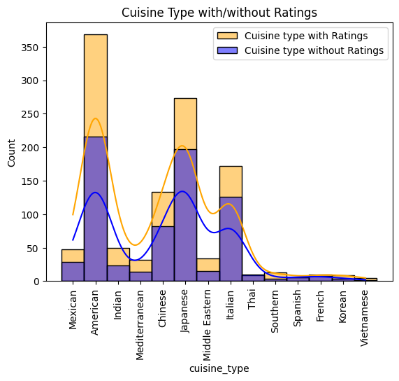

```python
# Shows an overview between the cuisine type and the lack of rating.
# Create a 2x2 grid of subplots

sns.histplot(data=df_original[df_original["rating"] != "Not given"], x="cuisine_type", color="orange", kde=True, label="Cuisine type with Ratings")
sns.histplot(data=df_original[df_original["rating"] == "Not given"], x="cuisine_type", color="blue", kde=True, label="Cuisine type without Ratings")
plt.legend()
plt.xticks(rotation=90)
plt.title("Cuisine Type with/without Ratings")
plt.show()
```

##### The density plots look the same for both cases. No relation can be attributed.

#### Let's check if there is any relationship with the delivery time and the cost of the order.

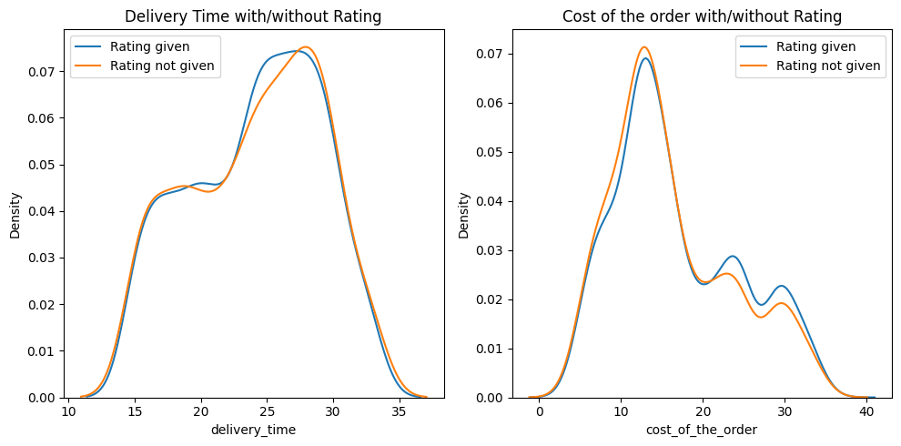

```python
# Create a 2x2 grid of subplots
fig, axs = plt.subplots(1, 2, figsize=(10, 5))

# Two graphs on the same plot to compare the behavior of the graphs.
sns.kdeplot(data=df_original[df_original["rating"] != "Not given"], x="delivery_time", ax=axs[0], label="Rating given")
sns.kdeplot(data=df_original[df_original["rating"] == "Not given"], x="delivery_time", ax=axs[0], label="Rating not given")
axs[0].legend()
axs[0].set_title("Delivery Time with/without Rating")

# Two graphs on the same plot to compare the behavior of the graphs.
sns.kdeplot(data=df_original[df_original["rating"] != "Not given"], x="cost_of_the_order", ax=axs[1], label="Rating given")
sns.kdeplot(data=df_original[df_original["rating"] == "Not given"], x="cost_of_the_order", ax=axs[1], label="Rating not given")
axs[1].legend()
axs[1].set_title("Cost of the order with/without Rating")

# Adjust layout for better spacing
plt.tight_layout()
plt.show()
```

##### The trends are the same, there is no logical reason to think that there is a relationship between delivery time and cost of the order with the presence/absence of rankings.

#### It is logical that not all orders have a rating since this is usually optional in delivery services. Moreover, there is not a relation between the orders without ratings with their cuisine type, cost of delivery or delivery time, which implies that it is just random. Let's treat the missing values with the mean rating of their respective cuisine.

```python
#First we make every "Not given" value into a NumPy NaN
df["rating"].replace("Not given", np.nan, inplace=True)

# Then we make every object an int
df["rating"] = pd.to_numeric(df["rating"])

# Then we transform the missing values with the mean value of their respective cuisine type
df["rating"] = df["rating"].fillna(value = df.groupby(["cuisine_type"])["rating"].transform("mean"))

# We then make them categorical again
df["rating"] = df["rating"].astype(int).astype(str)
print(df["rating"].value_counts())
```

```
rating
4    1122
5     588
3     188
Name: count, dtype: int64
```

##### By doing this we got rid of the missing values. Someone could argue that it would be better to leave them like they are, but also the method implemented is a good practice.

### **Question 4:** Check the statistical summary of the data. What is the minimum, average, and maximum time it takes for food to be prepared once an order is placed?

```python
# DEscribe the data includding non numerical values. It is transposed for visualization purposes.
df.describe(include="all").T
```

|  | count | unique | top | freq | mean | std | min | 25% | 50% | 75% | max |
| --- | --- | --- | --- | --- | --- | --- | --- | --- | --- | --- | --- |
| order_id | 1898 | 1898 | 1477147 | 1 | NaN | NaN | NaN | NaN | NaN | NaN | NaN |
| customer_id | 1898 | 1200 | 52832 | 13 | NaN | NaN | NaN | NaN | NaN | NaN | NaN |
| restaurant_name | 1898 | 178 | Shake Shack | 219 | NaN | NaN | NaN | NaN | NaN | NaN | NaN |
| cuisine_type | 1898 | 14 | American | 584 | NaN | NaN | NaN | NaN | NaN | NaN | NaN |
| cost_of_the_order | 1898.0 | NaN | NaN | NaN | 16.498851 | 7.483812 | 4.47 | 12.08 | 14.14 | 22.2975 | 35.41 |
| day_of_the_week | 1898 | 2 | Weekend | 1351 | NaN | NaN | NaN | NaN | NaN | NaN | NaN |
| rating | 1898 | 3 | 4 | 1122 | NaN | NaN | NaN | NaN | NaN | NaN | NaN |
| food_preparation_time | 1898.0 | NaN | NaN | NaN | 27.37197 | 4.632481 | 20.0 | 23.0 | 27.0 | 31.0 | 35.0 |
| delivery_time | 1898.0 | NaN | NaN | NaN | 24.161749 | 4.972637 | 15.0 | 20.0 | 25.0 | 28.0 | 33.0 |

#### Observations: The minimum time to prepare food is 20 minutes, the average time is 27.4 minutes, and the maximum is 35 minutes.

### **Question 5:** How many orders are not rated?

```python
# Write the code here
print(df_original[df_original["rating"] == "Not given"].shape[0])
```

```
736
```

#### Observations: 736 orders where not given a rating.

## Exploratory Data Analysis (EDA)

### **Question 6:** Explore all the variables and provide observations on their distributions. (Generally, histograms, boxplots, countplots, etc. are used for univariate exploration)

```python
# Recurrent clients? Let's check if someone has ordered more than once.
customer_df = df.groupby("customer_id")["order_id"].count()
# Let's visualize this. We are going to concatenate two DataFrames.
# One showing the number of clients that have ordered x times, and the
# other one showing the proportions.

results = pd.concat([customer_df.value_counts().sort_index(ascending = True),
                 customer_df.value_counts(normalize=True).sort_index(ascending = True)], axis=1)
results.columns = ["Nr. Users", "Proportion"]
results.index.name = "Nr. Orders"
print(results)
```

```
            Nr. Users  Proportion
Nr. Orders
1                 784    0.653333
2                 267    0.222500
3                  83    0.069167
4                  33    0.027500
5                  19    0.015833
6                   6    0.005000
7                   4    0.003333
8                   1    0.000833
9                   1    0.000833
10                  1    0.000833
13                  1    0.000833
```

##### 784 clients (65%) have ordered only once. Moreover, there is a loyal customer that has ordered 13 times. Furthermore, the vast majority (98.9%) has ordered less than 6 times.

#### Let's check if some restaurants are regularly consdiered.

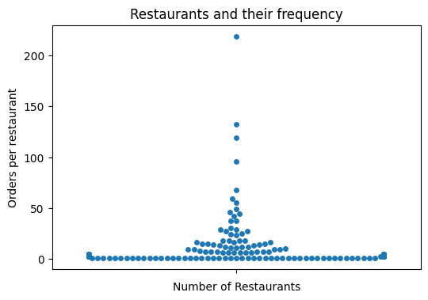

```
                                Number of Orders  Density of total orders
restaurant_name
Shake Shack                                 219                 0.115385
The Meatball Shop                           132                 0.069547
Blue Ribbon Sushi                           119                 0.062698
Blue Ribbon Fried Chicken                    96                 0.050580
Parm                                         68                 0.035827
RedFarm Broadway                             59                 0.031085
RedFarm Hudson                               55                 0.028978
TAO                                          49                 0.025817
Han Dynasty                                  46                 0.024236
Blue Ribbon Sushi Bar & Grill                44                 0.023182
```

```python
# Recurrent restaurants? Let's check if someone has ordered more than once from the same restaurant.
restaurants_df = df.groupby("restaurant_name")["order_id"].count()
restaurants_df.columns = ["Number of Orders"]

# Swarmplot to visualize the data
plt.figure(figsize=(6,4))
sns.swarmplot(restaurants_df)
plt.title("Restaurants and their frequency")
plt.xlabel("Number of Restaurants")
plt.ylabel("Orders per restaurant")
plt.show()

# Sort the restaurants from highest orders to lowest and show the first 10.
restaurants_df = pd.DataFrame(restaurants_df)
restaurants_df.columns = ["Number of Orders"]
restaurants_df["Density of total orders"] = restaurants_df["Number of Orders"]/restaurants_df["Number of Orders"].sum()
print("\n", restaurants_df.sort_values(by="Number of Orders", ascending=False).head(10))
```

##### Observations: There is clearly some restaurants with higher frequency of orders, which can be seen both from the table and the graph. Most of them have been ordered less than 20 times. The 5 most frequent restaurants represent 33% of all the orders.

#### Count of weekdays vs weekends. Count of ratings:

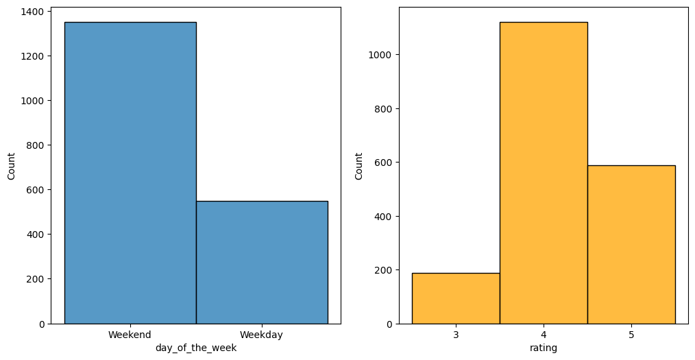

```python
# Visualization of two independent categorical columns
fig, axs = plt.subplots(1, 2, figsize=(12, 6))
sns.histplot(df["day_of_the_week"], ax=axs[0])
sns.histplot(df["rating"].sort_values(), ax=axs[1], color="orange")
plt.show()
```

##### Observations: Most people command of Weekends. On another hand, it is rare to see low ratings, more than two thirds of the given ratings are 4 or 5.

#### Numerical columns and their respective plots

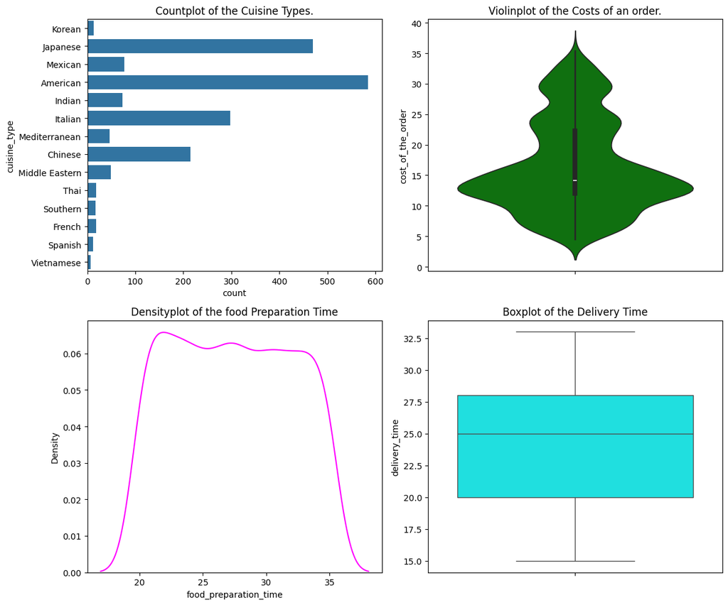

```python
# Create a 2x2 grid of subplots
fig, axs = plt.subplots(2, 2, figsize=(12, 10))

# Countplot of the Cuisine type
sns.countplot(data=df["cuisine_type"], ax=axs[0, 0])
axs[0, 0].set_title("Countplot of the Cuisine Types.")

# Violinplot of the Costs type
sns.violinplot(data=df["cost_of_the_order"], ax=axs[0, 1], color="Green")
axs[0, 1].set_title("Violinplot of the Costs of an order.")

# Density plot of the Food Preparation Time
sns.kdeplot(data=df["food_preparation_time"], ax=axs[1, 0], color="Magenta")
axs[1, 0].set_title("Densityplot of the food Preparation Time")

# Bocplot of the Delivery type
sns.boxplot(data=df["delivery_time"], ax=axs[1, 1], color="cyan")
axs[1, 1].set_title("Boxplot of the Delivery Time")

# Adjust layout for better spacing
plt.tight_layout()
plt.show()
```

### **Question 7**: Which are the top 5 restaurants in terms of the number of orders received?

```python
# Let's find the restaurants with mulitple orders
restaurants_df = df.groupby("restaurant_name")["order_id"].count()

# Sort the restaurants from highest orders to lowest and show the first 10.
print(restaurants_df.sort_values(ascending = False).head(5))
```

```
restaurant_name
Shake Shack                  219
The Meatball Shop            132
Blue Ribbon Sushi            119
Blue Ribbon Fried Chicken     96
Parm                          68
Name: order_id, dtype: int64
```

#### Top 5 Restaurants:

1. Shake Shack with 219 orders.
2. The Meatball Shop with 132 orders.
3. Blue Ribbon Sushi with 119 orders.
4. Blue Ribbon Fried Chicken with 96 orders.
5. Parm with 68 orders.

### **Question 8**: Which is the most popular cuisine on weekends?

```python
# First we extract only the weekend orders
weekend_df = df[df["day_of_the_week"] == "Weekend"]
# Then we look for the most popular cuisine.
weekend_df["cuisine_type"].value_counts().head(1)
```

| cuisine_type | count |
| --- | --- |
| American | 415 |

**dtype:** int64

##### The most popular cuisine on weekends is the American cuisine with 415 orders.

### **Question 9**: What percentage of the orders costs more than 20 dollars?

```
Percentage more than 20 USD: 31.995%
```

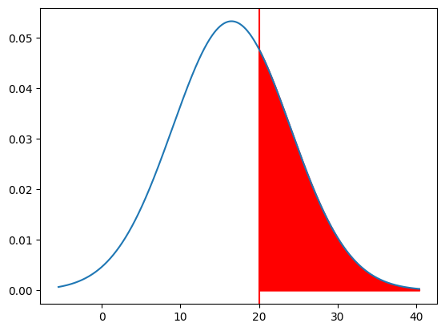

```python
# We define variables for all the parameters that will be relevant.
costs = df["cost_of_the_order"]
mu = costs.mean()
s = costs.std()
minimum = costs.min()
maximum = costs.max()
n = costs.shape[0]

# We find the percentage using the cumulative distribution function assuming normality since n is big (CLT).
print("Percentage more than 20 USD:", str(round((1 - stats.norm.cdf(20, mu, s))*100,3)) + "%\n")


# For visualization purposes:
# We create our x-axis vector based on the minimum, maximum and n variables.
x1 = np.linspace(minimum - 10, maximum + 5, n)
# We create our density function
costs_function = stats.norm.pdf(x=x1, loc = mu, scale = s)

# The red area is created for visualization purposes.
plt.axvline(20, color="red")
x2 = np.linspace(20, maximum + 5, 50)
plt.fill_between(x2, stats.norm.pdf(x2, mu, s), color="r")

#The plot is created
plt.plot(x1, costs_function)
plt.show()
```

##### Almost a third of the orders cost more than 20 USD.

### **Question 10**: What is the mean order delivery time?

```python
# We can directly find the mean
print("Mean order delivery time:", round(df["delivery_time"].mean(),3))
```

```
Mean order delivery time: 24.162
```

##### The mean order delivery time is 24 minutes and 10 seconds.

### **Question 11:** The company has decided to give 20% discount vouchers to the top 3 most frequent customers. Find the IDs of these customers and the number of orders they placed

```python
# We first group the dataframe by customer_id, then we count the orders.
# Then we sort them in descending order and get the first 3 values.
df.groupby("customer_id")["order_id"].count().sort_values(ascending=False).head(3)
```

| customer_id | order_id |
| --- | --- |
| 52832 | 13 |
| 47440 | 10 |
| 83287 | 9 |

**dtype:** int64

##### The top 3 most frequent customers:

1. Customer **52832** has ordered 13 times.
2. Customer **47440** has ordered 10 times.
3. Customer **83287** has ordered 9 times.

### **Question 12**: Perform a multivariate analysis to explore relationships between the important variables in the dataset. (It is a good idea to explore relations between numerical variables as well as relations between numerical and categorical variables)

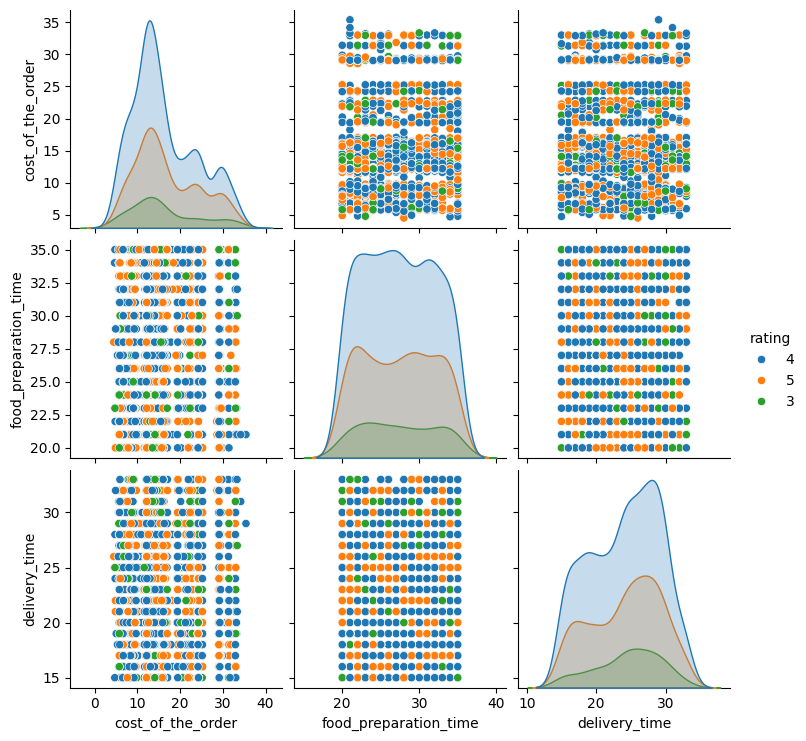

```python
# To start with the multivariate Analyisis, we can use the pairplot.
# We use the hue of rating to see if we identify some patterns.
sns.pairplot(df, hue = "rating")
```

##### It seems that there is no relationship... therefore, we are going to plot a heatmap to make sure that our assumption is correct.

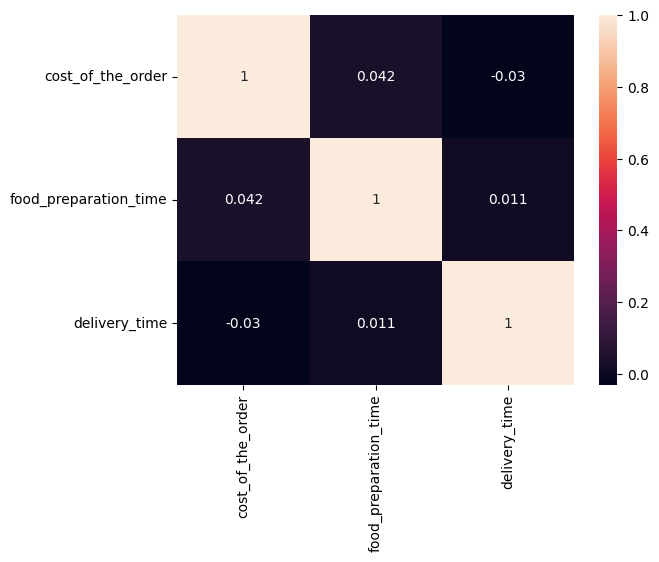

```python
sns.heatmap(data=df[["cost_of_the_order", "food_preparation_time", "delivery_time"]].corr(), annot = True)
```

##### No linear correlatin has been found, therefore let's do some numerical vs categorial analysis to try to generate some valuable insight.

#### Let's analyze the cost of the order per cuisine to gain insight.

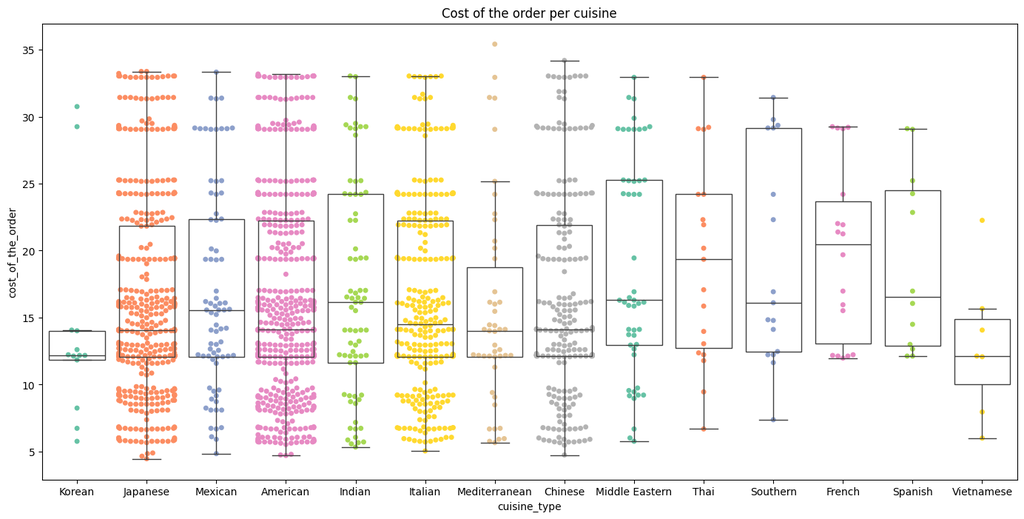

```python
# Advanced visualization technique to show a boxplot on top of a swarmplot
plt.figure(figsize=(17,8))
sns.boxplot(data = df, x="cuisine_type", y="cost_of_the_order", boxprops={'facecolor':'None'}, showfliers=False)
sns.swarmplot(data = df, x = "cuisine_type", y="cost_of_the_order", palette="Set2", zorder=0.5)
plt.title("Cost of the order per cuisine")
plt.show()
```

#### Let's analyze the total time of the order per cuisine to gain insight.

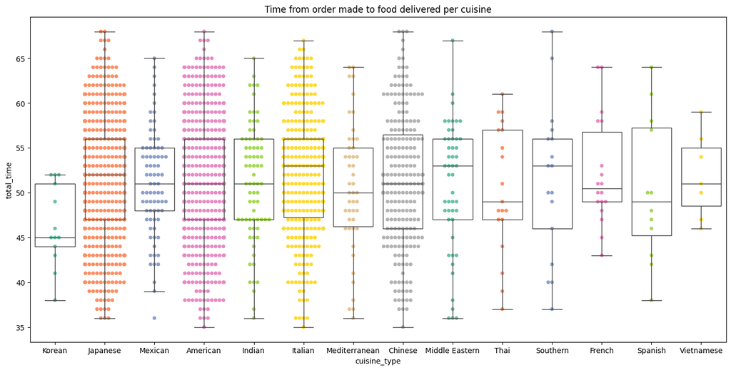

```python
# A new column is created to invetigate its relationship with the cuisine type
df["total_time"] = df["food_preparation_time"] + df["delivery_time"]

# Advanced visualization technique to show a boxplot on top of a swarmplot
plt.figure(figsize=(17,8))
sns.boxplot(data = df, x="cuisine_type", y="total_time", boxprops={'facecolor':'None'}, showfliers=False)
sns.swarmplot(data = df, x = "cuisine_type", y="total_time", palette="Set2", zorder=0.5)
plt.title("Time from order made to food delivered per cuisine")
plt.show()
```

#### Let's analyze the total time of an order with regard to its rating to gain insight.

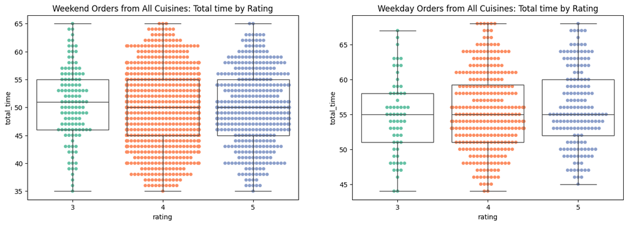

```python
# Advanced visualization technique to show a boxplot on top of a swarmplot. Two plots next to each other variying on the weekday/weekend criteria
fig, axs = plt.subplots(1, 2, figsize=(16, 5))
sns.boxplot(data = df[df["day_of_the_week"] == "Weekend"].sort_values(by="rating"), x = "rating", y="total_time", boxprops={'facecolor':'None'}, showfliers=False, ax=axs[0])
sns.swarmplot(data = df[df["day_of_the_week"] == "Weekend"].sort_values(by="rating"), x = "rating", y="total_time", palette="Set2", zorder=0.5, ax=axs[0])
axs[0].set_title("Weekend Orders from All Cuisines: Total time by Rating")
sns.boxplot(data = df[df["day_of_the_week"] != "Weekend"].sort_values(by="rating"), x = "rating", y="total_time", boxprops={'facecolor':'None'}, showfliers=False, ax=axs[1])
sns.swarmplot(data = df[df["day_of_the_week"] != "Weekend"].sort_values(by="rating"), x = "rating", y="total_time", palette="Set2", zorder=0.5, ax=axs[1])
axs[1].set_title("Weekday Orders from All Cuisines: Total time by Rating")
plt.show()
```

##### We quickly realize that Food is ordered way more on weekends. Moreover, there is an important difference depicted by these graphs. The low ratings on weekends have a high median on weekends, meaning they are given often when the total time is large. However, on the weekdays this is not the case. This could depict that in weekends people have less things to do and that they value more getting the food fast.

#### Let's check the ratings per cuisine for both the original database and the one with refined ratings based on the mean value.

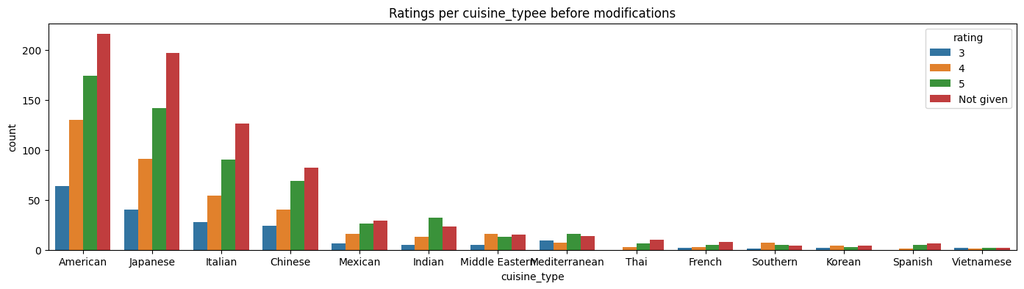

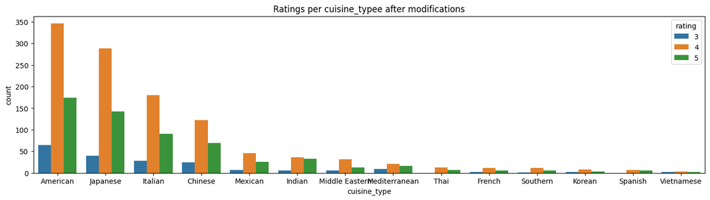

```python
# Countplot of cuisine type per rating before the rating manipulation.
plt.figure(figsize=(17,4))
order = df["cuisine_type"].value_counts().index
sns.countplot(data=df_original.sort_values(by="rating"), x="cuisine_type", hue="rating", order = order)
plt.title("Ratings per cuisine_typee before modifications")
plt.show()

# Countplot of cuisine type per rating after the rating manipulation.
plt.figure(figsize=(17,4))
sns.countplot(data=df.sort_values(by="rating"), x="cuisine_type", hue="rating", order = order)
plt.title("Ratings per cuisine_typee after modifications")
plt.show()
```

#### Evidently the ratings dont have much impact in the cuisines since all cuisines follow a similar trend (both before and after the rating modifications respectively). Maybe it is worth mentioning that most people that order from the Indian cuisine leave a positive review.

### **Question 13:** The company wants to provide a promotional offer in the advertisement of the restaurants. The condition to get the offer is that the restaurants must have a rating count of more than 50 and the average rating should be greater than 4. Find the restaurants fulfilling the criteria to get the promotional offer

```python
# We first create a copy considering only the orders wit a given rating. Then we transform the ratings into type int.
find_promotion_df = df_original[df_original["rating"] != "Not given"].copy()
find_promotion_df["rating"] = find_promotion_df["rating"].astype(int)

# We find those restaurants with more than 50 given ratings.
fifty_ratings = find_promotion_df["restaurant_name"].value_counts()
fifty_ratings = fifty_ratings[fifty_ratings > 50]

# We find those restaurants with more than 4 given rating average.
greater_than_4 = find_promotion_df[find_promotion_df["rating"] != "Not given"].groupby("restaurant_name")["rating"].mean()
greater_than_4 = greater_than_4[greater_than_4 > 4]

# We concatenate both pandas Series on the condition that a given index exist in  both Series ("inner join")
promotion_restaurants = pd.concat([fifty_ratings, greater_than_4], axis=1, join='inner')
print(promotion_restaurants)
```

```
                           count    rating
restaurant_name
Shake Shack                  133  4.278195
The Meatball Shop             84  4.511905
Blue Ribbon Sushi             73  4.219178
Blue Ribbon Fried Chicken     64  4.328125
```

##### Restaurants fulfilling the criteria for promotion:

1. Shake Shack
2. The Metaball Shop
3. Blue Ribbon Sushi
4. Blue Ribbon Fried Chicken

### **Question 14:** The company charges the restaurant 25% on the orders having cost greater than 20 dollars and 15% on the orders having cost greater than 5 dollars. Find the net revenue generated by the company across all orders

```python
# We define our accumulator to find the total revenue
total_revenue = 0

# We find the orders in the range of prices of 5 < row <= 20
between_5_and_20_df = df[(df["cost_of_the_order"] > 5) & (df["cost_of_the_order"] <= 20)]
# We add this revenue to our variable.
total_revenue += (between_5_and_20_df["cost_of_the_order"]*0.15).sum()

# We find the orders in the range of prices of 5 < row <= 20
more_tan_20_df = df[df["cost_of_the_order"] > 20]
# We add this revenue to our variable.
total_revenue += (more_tan_20_df["cost_of_the_order"]*0.25).sum()

print("The net revenue generated by the company across all orders is: $" + str(round(total_revenue,2)) + " USD.")
```

```
The net revenue generated by the company across all orders is: $6166.3 USD.
```

##### The company has generated $6166.3 USD from these 2 conditions

### **Question 15:** The company wants to analyze the total time required to deliver the food. What percentage of orders take more than 60 minutes to get delivered from the time the order is placed? (The food has to be prepared and then delivered)

```
Percentage more than 60 minutes: 10.769%
```

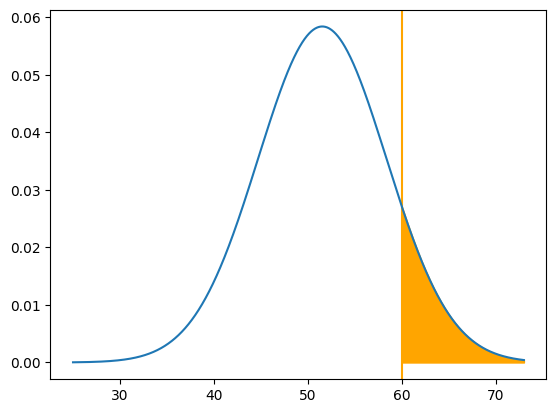

```python
# We define variables for all the parameters that will be relevant.
total_time = df["total_time"]
mu = total_time.mean()
s = total_time.std()
minimum = total_time.min()
maximum = total_time.max()
n = total_time.shape[0]

# We find the percentage using the cumulative distribution function assuming normality since n is big (CLT).
print("Percentage more than 60 minutes:", str(round((1 - stats.norm.cdf(60, mu, s))*100,3)) + "%\n")


# For visualization purposes:
# We create our x-axis vector based on the minimum, maximum and n variables.
x1 = np.linspace(minimum - 10, maximum + 5, n)
# We create our density function
total_time_function = stats.norm.pdf(x=x1, loc = mu, scale = s)

# The red area is created for visualization purposes.
plt.axvline(60, color="orange")
x2 = np.linspace(60, maximum + 5, 50)
plt.fill_between(x2, stats.norm.pdf(x2, mu, s), color="orange")

#The plot is created
plt.plot(x1, total_time_function)
plt.show()
```

##### Only 10.77% of the orders take more than one hour to be delivered.

### **Question 16:** The company wants to analyze the delivery time of the orders on weekdays and weekends. How does the mean delivery time vary during weekdays and weekends?

```python
# Write the code here
print("The mean delivery time on weekdays is:", round(df[df["day_of_the_week"] == "Weekday"]["delivery_time"].mean(),3), "minutes.")
print("The mean delivery time on weekends is:", round(df[df["day_of_the_week"] == "Weekend"]["delivery_time"].mean(),3), "minutes.")
```

```
The mean delivery time on weekdays is: 28.34 minutes.
The mean delivery time on weekends is: 22.47 minutes.
```